# Bellabeat Report

Julia Britland

2023-10-10

# Introduction

Bellabeat is a smart-product manufacturer that makes health and fitness consumer devices for women. Their main products are an app for tracking habits/cycles, several smart devices for tracking health data, and a subscription for personalized advice.

This analysis seeks identify opportunities for growth. It seeks for trends in smart device usage and makes recommendations on how Bellabeat can attract more customers.

# Data Source

This analysis served as a learning experience and an exploration of R; therefore, only one data source was used. The data can be found at this [link](https://www.kaggle.com/datasets/arashnic/fitbit) and was posted by the Kaggle user Mobius.

- dailyActivities_merged.csv
- sleepDay_merged.csv
- weightLogInfo_merged.csv

# Data cleaning and manipulation

The fields used for this analysis had no missing values. However, the sleep table contained several duplicate entries that were removed. Field names were changed to snake case. The Id in each table was changed to a string and the dates in each table were parsed and converted to a Date. The tables were all combined by matching the Id and date; this resulted in some blank fields that had to be handled during analysis because activity was more consistently reported than sleep or weight. A week number field was added.

# Analysis

The following insights were gained about the fitness device users.

## When did users use their devices?

This analyst found that while many users consistently used their devices to track their activity, fewer used them to track sleep, and even fewer used them to track weight. Additionally, it was noted that as time went on, there were fewer records overall, indicating that people wore their devices less the longer they had them. The following graph shows these trends:

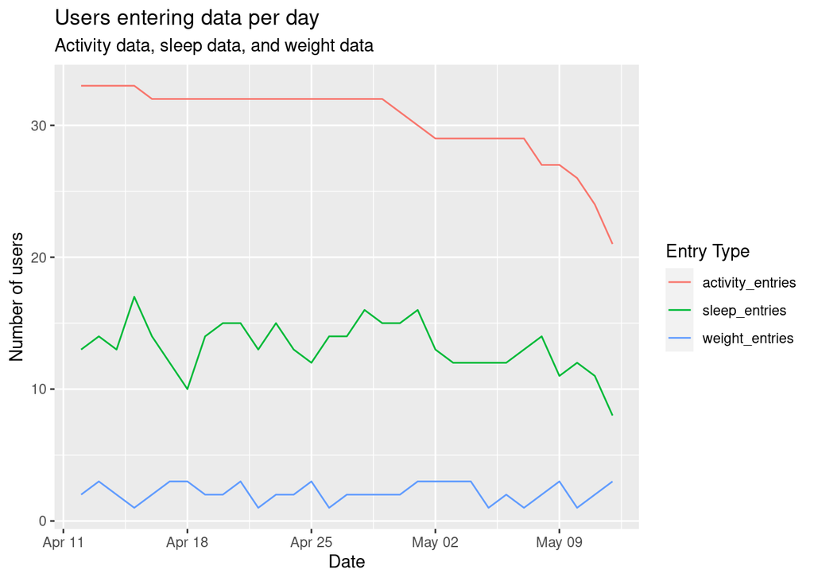

A possible explanation of the lack of reporting for sleep is that people found the devices uncomfortable to wear to sleep.

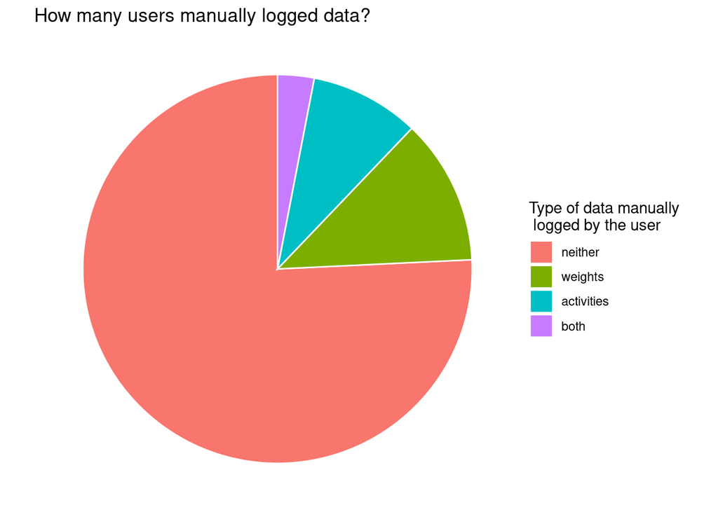

As seen here, more than three quarters of participants never used their device to manually log data of either type.

Thus, we can see that comfort and convenience are two key factors in determining how a user uses their smart fitness devices.

## Physical activity over time

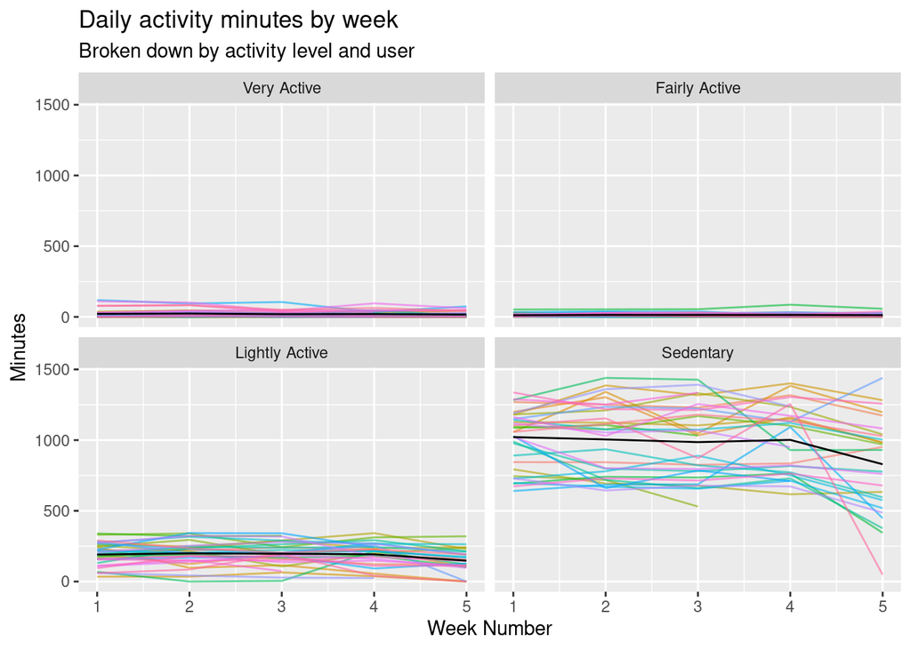

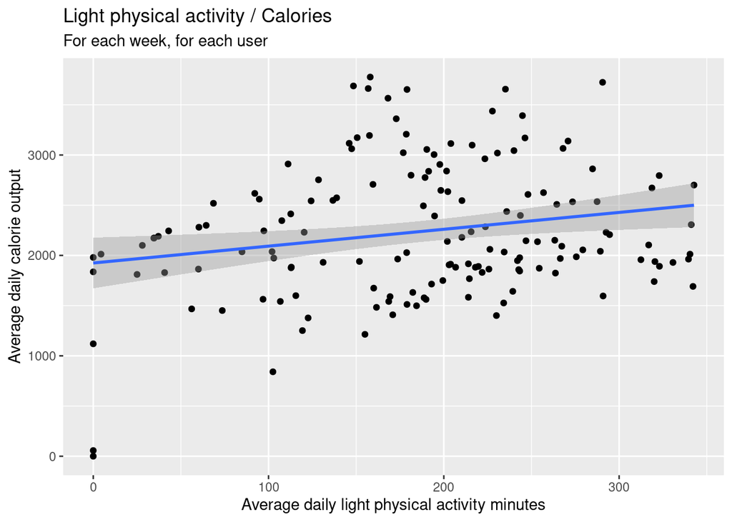

While an extra 100 calories per day may not seem like a lot, it can add up over time to help maintain or lose weight. This shows that light physical activity could be a attainable and useful target for improving fitness.

## Further analysis to come

Again, this analysis was a learning and exploratory experience. The conclusions drawn above are not the only ones possible and in fact there is more that could be discussed here; however, this analyst will have to return at a later date as she has other learning tasks awaiting. However, this was a useful exercise and will help to guide future analyses.

# Recommendations

Based on the data analyzed in this report, three recommendations are presented.

## Use the app to decrease drop-off

Users tended to stop using their devices over time. The Bellabeat app presents a useful tool to remind users to be consistent. The app can send notifications to keep users on track.

## Emphasize effortlessness

This data showed that lack of comfort or convenience could present barriers to device usage. Finding ways to address these issues could give Bellabeat a competitive edge. The R&D team could look for ways to improve comfort, such as different materials or more personalized fit, while the marketing team could team up with smart scale manufacturers to emphasize convenience. The product team should focus more on developing an intuitive user interface for viewing information rather than focusing on creating new ways to log information as this feature is not valued by many users.

Overall, these three recommendations can help guide marketing to create new business for Bellabeat and improve relationships with existing customers.